# Analisis Clustering Concrete Compressive Strength Dataset

# D. Clustering

## 1. K-Means Clustering

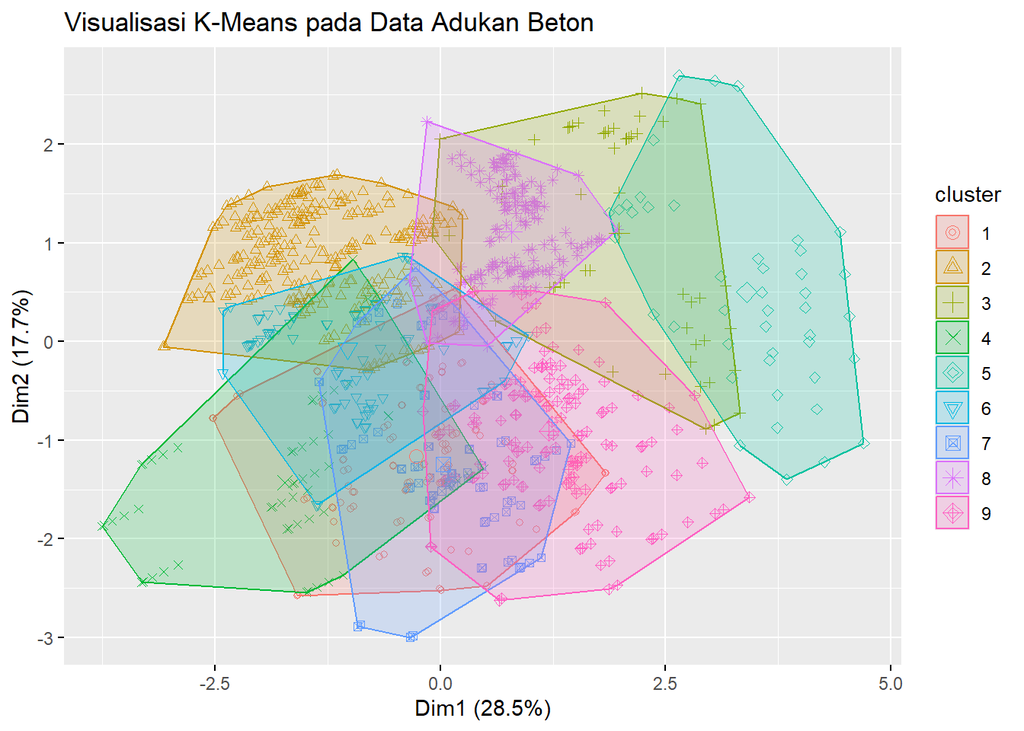

```r
set.seed(020)
km_res <- kmeans(df_scaled, centers = k_optimal, nstart = 25)

# Visualisasi Hasil K-Means
fviz_cluster(km_res, data = df_scaled, geom = "point",
             main = "Visualisasi K-Means pada Data Adukan Beton",
             ellipse.type = "convex")
```

```r
# Menghitung dan menyimpan rata-rata Silhouette Score
sil_km <- silhouette(km_res$cluster, dist(df_scaled))
avg_sil_km <- mean(sil_km[, 3])
cat("Rata-rata Silhouette Score (K-Means):", avg_sil_km, "\n")
```

```
## Rata-rata Silhouette Score (K-Means): 0.280914
```

Hal yang bisa disimpulkan dari grafik ini adalah banyaknya tumpukan antar area cluster (misalnya cluster 3, 4, 5, dan 6 posisinya saling tabrakan).

## 2. Hierarchical Clustering : Complete Linkage

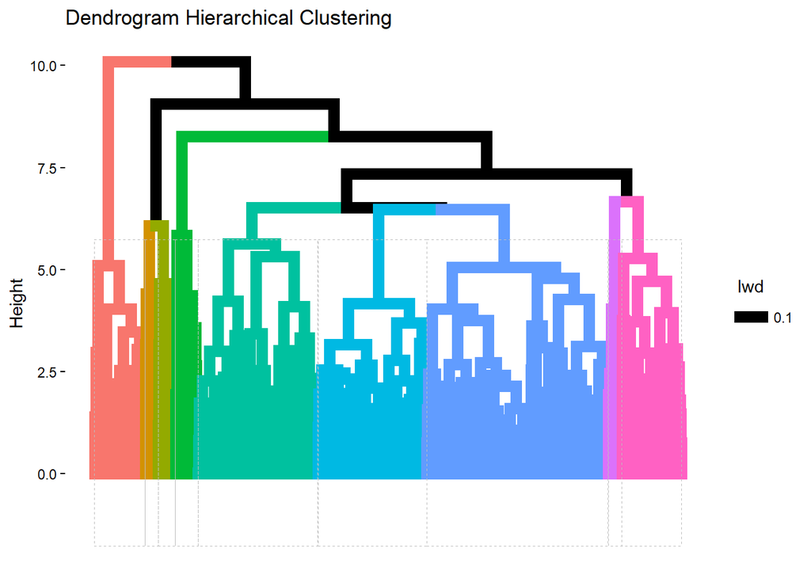

```r
# Menghitung matriks jarak Euclidean
d <- dist(df_scaled, method = "euclidean")

# Membuat model Hierarchical Clustering : Complete Linkage
hc_res <- hclust(d, method = "complete")

# Memotong dendrogram sesuai jumlah cluster optimal
hc_clusters <- cutree(hc_res, k = k_optimal)

# Visualisasi Dendrogram
fviz_dend(hc_res, k = k_optimal, rect = TRUE, show_labels = FALSE, lwd = 0.1,
          main = "Dendrogram Hierarchical Clustering")
```

```r
# Menghitung dan menyimpan rata-rata Silhouette Score
sil_hc <- silhouette(hc_clusters, d)
avg_sil_hc <- mean(sil_hc[, 3])
cat("Rata-rata Silhouette Score (Hierarchical):", avg_sil_hc, "\n")
```

```
## Rata-rata Silhouette Score (Hierarchical): 0.2042538
```

Berdasarakan dendogram tersebut, data beton yang berada di dalam warna yang sama berarti mereka dikelompokkan ke dalam satu cluster yang sama karena karakteristik mereka mirip.

# Validation & Kesimpulan

```r
# Tabel Perbandingan
comparison <- data.frame(
  Metode = c("K-Means", "Hierarchical (Complete)"),
  Average_Silhouette = c(avg_sil_km, avg_sil_hc)
)
# Menampilkan hasil
comparison %>% arrange(desc(Average_Silhouette))
```

```
##                    Metode Average_Silhouette
## 1                 K-Means          0.2809140
## 2 Hierarchical (Complete)          0.2042538
```

Berdasarkan tabel karena K-Means memiliki Silhouette Score lebih tinggi, metode K-Means terbukti lebih cocok untuk memetakan variasi komposisi beton dibandingkan Hierarchical Clustering.